# Anaylsis of ATAC-seq in embryos depleted for Zelda

## 7.3. Plot average profiles

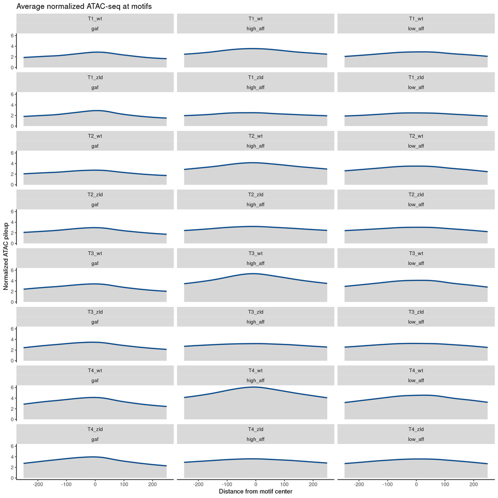

```r
source("/l/Zeitlinger/ZeitlingerLab/Manuscripts/Zelda_and_Nucleosomes/Analysis/analysis/scripts/r/metapeak_extra.r")

# Define function

get_multi_gr_bw_standard_metapeak <- function(gr.list = gr.list, bw.list = bw.list, upstream = 250, downstream = 250, smooth = NA){
  mclapply(names(gr.list), function(x){
    gr <- gr.list[[x]]
    get_multi_bw_standard_metapeak(gr,bw.list, upstream = upstream, downstream = downstream, smooth = smooth) %>% mutate(grange_name = x) # The sample_name will be the bw name
  },mc.cores = 10) %>% bind_rows() %>% rename(bw_name = sample_name)
}

# Define coverage list

bw.list<-list(`T1_wt` = '/l/Zeitlinger/ZeitlingerLab/Manuscripts/Zelda_and_Nucleosomes/Analysis/data/bw/dm6/atac/combined/orer_1to15_atac_combined_normalized.bw',
              `T2_wt` = '/l/Zeitlinger/ZeitlingerLab/Manuscripts/Zelda_and_Nucleosomes/Analysis/data/bw/dm6/atac/combined/orer_15to2_atac_combined_normalized.bw',
              `T3_wt` = '/l/Zeitlinger/ZeitlingerLab/Manuscripts/Zelda_and_Nucleosomes/Analysis/data/bw/dm6/atac/combined/orer_2to25_atac_combined_normalized.bw',
              `T4_wt` = '/l/Zeitlinger/ZeitlingerLab/Manuscripts/Zelda_and_Nucleosomes/Analysis/data/bw/dm6/atac/combined/orer_25to3_atac_combined_normalized.bw',
              `T1_zld` = '/l/Zeitlinger/ZeitlingerLab/Manuscripts/Zelda_and_Nucleosomes/Analysis/data/bw/dm6/atac/combined/zldrnai_1to15_atac_combined_normalized.bw',
              `T2_zld` = '/l/Zeitlinger/ZeitlingerLab/Manuscripts/Zelda_and_Nucleosomes/Analysis/data/bw/dm6/atac/combined/zldrnai_15to2_atac_combined_normalized.bw',
              `T3_zld` = '/l/Zeitlinger/ZeitlingerLab/Manuscripts/Zelda_and_Nucleosomes/Analysis/data/bw/dm6/atac/combined/zldrnai_2to25_atac_combined_normalized.bw',
              `T4_zld` = '/l/Zeitlinger/ZeitlingerLab/Manuscripts/Zelda_and_Nucleosomes/Analysis/data/bw/dm6/atac/combined/zldrnai_25to3_atac_combined_normalized.bw')

# Plot

atac_at_zld_aff.mp <- get_multi_gr_bw_standard_metapeak(gr.list = zld_aff.list, bw.list = bw.list, upstream = 250, downstream = 250, smooth = 2)

atac_at_zld_aff.plot <- ggplot(atac_at_zld_aff.mp, aes(x=tss_distance, y=reads)) +
         geom_area(position="identity", alpha = 0.2) +
         geom_smooth(method = "loess", span = 0.3, color = "dodgerblue4")+
         ggtitle("Average normalized ATAC-seq at motifs") +
            facet_wrap(bw_name ~ grange_name, scales = "fixed", ncol = 3) +
            theme(legend.position = "none") +
            theme(panel.grid.major = element_blank(), panel.grid.minor = element_blank(),
            panel.background = element_blank(), axis.line.x = element_line(colour = "black"),
            axis.line.y = element_line(colour = "black")) +
            xlab("Distance from motif center") +
            ylab("Normalized ATAC pileup")
atac_at_zld_aff.plot
```

```r
ggsave("atacseq_over_time_average_plots_at_motifs_by_zld_affinity_250_motifs_only.pdf", plot = atac_at_zld_aff.plot, path = "figures/14_zelda_depletion_atac", width = 40, height = 20, units = "cm")
ggsave("atacseq_over_time_average_plots_at_motifs_by_zld_affinity_250_motifs_only.png", plot = atac_at_zld_aff.plot, path = "figures/14_zelda_depletion_atac", width = 40, height = 20, units = "cm")
```

## 7.4. Plot boxplots for quantification

```r
# Calculate

atac_across_high_aff_zld.df <- mclapply(names(bw.list), function(x){
regionSums(zld_high_top250_contrib_resized.gr %>% resize(500, 'center'), bw.list[[x]])
}, mc.cores = 4) %>% as.data.frame()
names(atac_across_high_aff_zld.df)<-names(bw.list)

atac_across_low_aff_zld.df <- mclapply(names(bw.list), function(x){
regionSums(zld_low_btm250_contrib_resized.gr %>% resize(500, 'center'), bw.list[[x]])
}, mc.cores = 4) %>% as.data.frame()
names(atac_across_low_aff_zld.df)<-names(bw.list)

atac_across_gaf.df <- mclapply(names(bw.list), function(x){
regionSums(gaf_subset_resized.gr %>% resize(500, 'center'), bw.list[[x]])
}, mc.cores = 4) %>% as.data.frame()
names(atac_across_gaf.df)<-names(bw.list)

# Merge with regions

zld_high_top250_contrib_resized_w_calc.df <- cbind(zld_high_top250_contrib_resized.gr %>% as.data.frame, atac_across_high_aff_zld.df) %>%
  dplyr::select(seq_match_cat, T1_wt, T2_wt, T3_wt, T4_wt, T1_zld, T2_zld, T3_zld, T4_zld) %>%
  as.data.table %>%
  melt.data.table(id.vars = c('seq_match_cat'), variable.name = 'timepoint', value.name = 'ATAC_signal')

zld_low_btm250_contrib_resized_w_calc.df <- cbind(zld_low_btm250_contrib_resized.gr %>% as.data.frame, atac_across_low_aff_zld.df) %>%
  dplyr::select(seq_match_cat, T1_wt, T2_wt, T3_wt, T4_wt, T1_zld, T2_zld, T3_zld, T4_zld) %>%
  as.data.table %>%
  melt.data.table(id.vars = c('seq_match_cat'), variable.name = 'timepoint', value.name = 'ATAC_signal')

gaf_250_contrib_resized_w_calc.df <- cbind(gaf_subset_resized.gr %>% as.data.frame, atac_across_gaf.df) %>%
  dplyr::select(pattern_name, T1_wt, T2_wt, T3_wt, T4_wt, T1_zld, T2_zld, T3_zld, T4_zld) %>%
  dplyr::rename(seq_match_cat = pattern_name) %>%
  as.data.table %>%
  melt.data.table(id.vars = c('seq_match_cat'), variable.name = 'timepoint', value.name = 'ATAC_signal')

# Combine

aff_regions_for_boxplot.df <- rbind(zld_high_top250_contrib_resized_w_calc.df, zld_low_btm250_contrib_resized_w_calc.df, gaf_250_contrib_resized_w_calc.df)

# Plot

aff_box_order <- c("T1_wt", "T1_zld", "T2_wt", "T2_zld", "T3_wt", "T3_zld", "T4_wt", "T4_zld")
aff_regions_for_boxplot.df$timepoint <- factor(aff_regions_for_boxplot.df$timepoint, levels = aff_box_order)
my_aff_comparisons <- list(c("T1_wt", "T1_zld"), c("T2_wt", "T2_zld"),
                       c("T3_wt", "T3_zld"), c("T4_wt", "T4_zld"))

aff_box <- ggplot(aff_regions_for_boxplot.df, aes(x = timepoint, y = log2(ATAC_signal))) +
  geom_boxplot(aes(fill = seq_match_cat)) +
  facet_wrap(~seq_match_cat) +
  stat_compare_means(comparisons = my_aff_comparisons, method = "wilcox.test", label = "p.signif", paired = FALSE, label.y = 13) +
  theme_cowplot()

ggsave("atacseq_over_time_average_plots_at_motifs_by_affinity_250_motifs_only_box.pdf", plot = aff_box, path = "figures/14_zelda_depletion_atac", width = 40, height = 20, units = "cm")
ggsave("atacseq_over_time_average_plots_at_motifs_by_affinity_250_motifs_only_box.png", plot = aff_box, path = "figures/14_zelda_depletion_atac", width = 40, height = 20, units = "cm")

# Calculate median values

library(plyr)

ddply(zld_high_top250_contrib_resized_w_calc.df, .(timepoint), summarise, med = median(log2(ATAC_signal)))
```

```
##   timepoint       med
## 1     T1_wt  9.729436
## 2     T2_wt  9.986781
## 3     T3_wt 10.346702
## 4     T4_wt 10.581893
## 5    T1_zld  9.210156
## 6    T2_zld  9.621180
## 7    T3_zld  9.749371
## 8    T4_zld  9.866239
```

```r
ddply(zld_low_btm250_contrib_resized_w_calc.df, .(timepoint), summarise, med = median(log2(ATAC_signal)))
```

```
##   timepoint       med
## 1     T1_wt  9.406510
## 2     T2_wt  9.814050
## 3     T3_wt  9.962798
## 4     T4_wt 10.036995
## 5    T1_zld  9.343237
## 6    T2_zld  9.683323
## 7    T3_zld  9.781562
## 8    T4_zld  9.854610
```

```r
ddply(gaf_250_contrib_resized_w_calc.df, .(timepoint), summarise, med = median(log2(ATAC_signal)))
```

```
##   timepoint      med
## 1     T1_wt 9.210196
## 2     T2_wt 9.394424
## 3     T3_wt 9.599358
## 4     T4_wt 9.754007
## 5    T1_zld 9.265827
## 6    T2_zld 9.453093
## 7    T3_zld 9.676563
## 8    T4_zld 9.769031
```

```r
ddply(zld_high_top250_contrib_resized_w_calc.df, .(timepoint), summarise, med = median(ATAC_signal))
```

```
##   timepoint       med
## 1     T1_wt  848.8952
## 2     T2_wt 1014.6658
## 3     T3_wt 1302.1781
## 4     T4_wt 1532.7362
## 5    T1_zld  592.2886
## 6    T2_zld  787.5604
## 7    T3_zld  860.7029
## 8    T4_zld  933.3597
```

```r
ddply(zld_low_btm250_contrib_resized_w_calc.df, .(timepoint), summarise, med = median(ATAC_signal))
```

```
##   timepoint       med
## 1     T1_wt  678.6438
## 2     T2_wt  900.1694
## 3     T3_wt  997.9326
## 4     T4_wt 1050.6001
## 5    T1_zld  649.5231
## 6    T2_zld  822.1892
## 7    T3_zld  880.1238
## 8    T4_zld  925.8398
```

```r
ddply(gaf_250_contrib_resized_w_calc.df, .(timepoint), summarise, med = median(ATAC_signal))
```

```
##   timepoint      med
## 1     T1_wt 592.3073
## 2     T2_wt 672.9843
## 3     T3_wt 775.7039
## 4     T4_wt 863.4727
## 5    T1_zld 615.5903
## 6    T2_zld 700.9148
## 7    T3_zld 818.3440
## 8    T4_zld 872.5254
```

## 7.5. Plot ChromBPNet predicted profiles at highest and lowest affinity Zelda motifs before and after motif mutation

```r
# Import ChromBPNet predictions generated in 7_acc_genomic_perturbs.ipynb and take only the center 500 bp since that's what we used for experimental plots

chrom.pred.df <- readr::read_tsv('/l/Zeitlinger/ZeitlingerLab/Manuscripts/Zelda_and_Nucleosomes/Analysis/analysis/tsv/perturbs/accessibility/zld_only_affinities_metapeaks.tsv.gz') %>%
  as.data.frame()
chrom.pred.intermediate.df <- chrom.pred.df[chrom.pred.df$position > 249,]
chrom.pred.sized.df <- chrom.pred.intermediate.df[chrom.pred.intermediate.df$position < 751,]
# Plot metapeaks

metapeaks.pred <- ggplot(chrom.pred.sized.df, aes(x = position, y = pred)) +
  geom_line(aes(linetype = mut)) +
  facet_grid(timepoint~motif_class) +
  theme_cowplot()

ggsave("atacseq_over_time_average_plots_at_motifs_by_zld_affinity_250_motifs_only_chrom_pred.pdf", plot = metapeaks.pred, path = "figures/14_zelda_depletion_atac", width = 40, height = 20, units = "cm")
ggsave("atacseq_over_time_average_plots_at_motifs_by_zld_affinity_250_motifs_only_chrom_pred.png", plot = metapeaks.pred, path = "figures/14_zelda_depletion_atac", width = 40, height = 20, units = "cm")
```

## 7.6. Plot sequence logos for highest and lowest affinity Zelda motifs

```r
library(ggseqlogo)

zld_high_top250_contrib.seq <- as.data.frame(getSeq(BSgenome.Dmelanogaster.UCSC.dm6, zld_high_top250_contrib.gr))
zld_low_btm250_contrib.seq <- as.data.frame(getSeq(BSgenome.Dmelanogaster.UCSC.dm6, zld_low_btm250_contrib.gr))
gaf_only_high_top250_contrib.seq <- as.data.frame(getSeq(BSgenome.Dmelanogaster.UCSC.dm6, gaf_subset.gr))

zld_top_250_logo <- ggplot() + geom_logo(zld_high_top250_contrib.seq) + theme_logo() + ggtitle("seq_match_cat == high, top 250 ordered by contrib")
zld_bottom_250_logo <- ggplot() + geom_logo(zld_low_btm250_contrib.seq) + theme_logo() + ggtitle("seq_match_cat == low, bottom 250 ordered by contrib")
gaf_250_logo <- ggplot() + geom_logo(gaf_only_high_top250_contrib.seq) + theme_logo() + ggtitle("seq_match_cat == high, 250 motifs")

zld_top_bottom.logo <- zld_top_250_logo + zld_bottom_250_logo + gaf_250_logo

ggsave("single_zld_affinity_logos_top_bottom_250.pdf", plot = zld_top_bottom.logo, path = "figures/14_zelda_depletion_atac", height = 6, width = 28)
ggsave("single_zld_affinity_logos_top_bottom_250.png", plot = zld_top_bottom.logo, path = "figures/14_zelda_depletion_atac", height = 6, width = 28)
```

## 7.7 Plot individual examples of high and low affinity Zelda motifs, with GAF as a control

Here, we selected individual examples by looking at the associated bigwig files in the IGV genome browser and looking at individual high and low affinity motifs that were organized in the above code. The following at the genomic coordinates for our examples:

Zelda high affinity: chr2R:16838950-16839450 Zelda low affinity: chr2L:19636680-19637180 GAF: chr3R:15,313,850-15,314,350

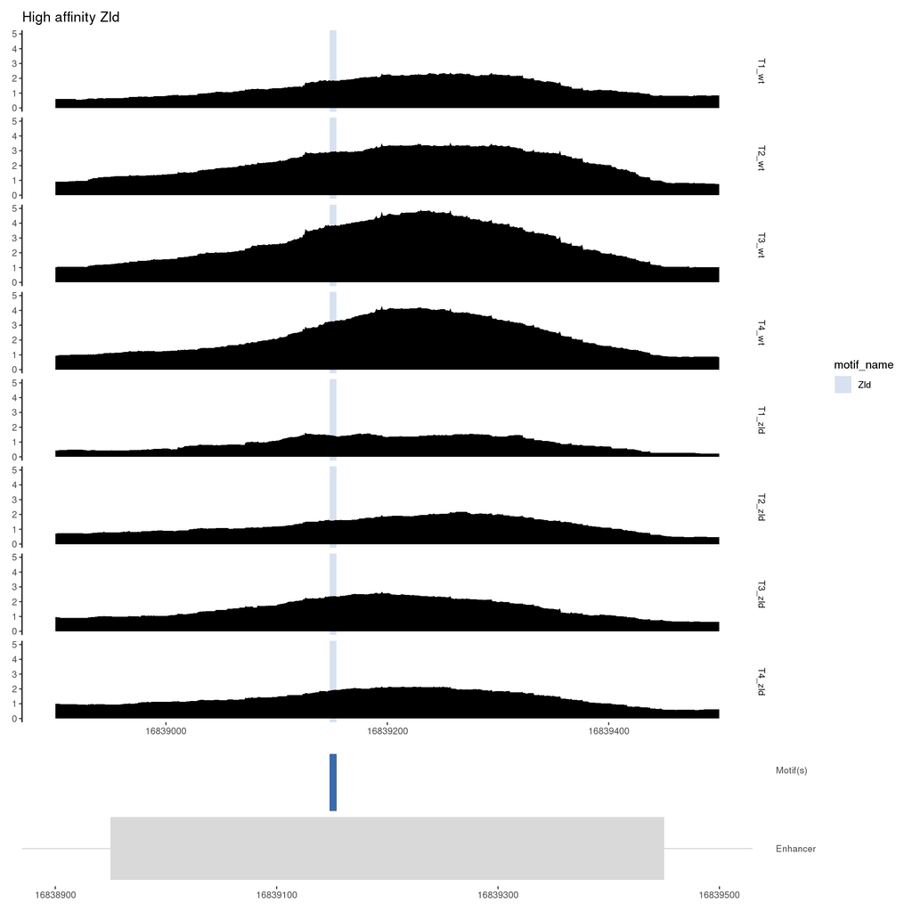

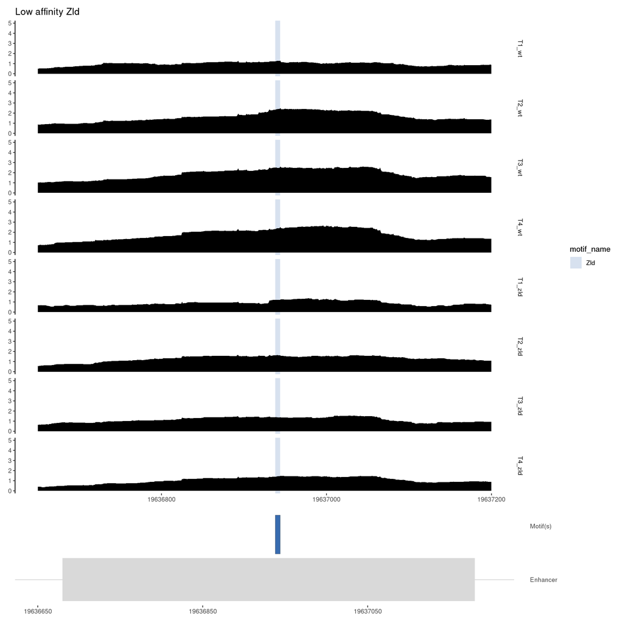

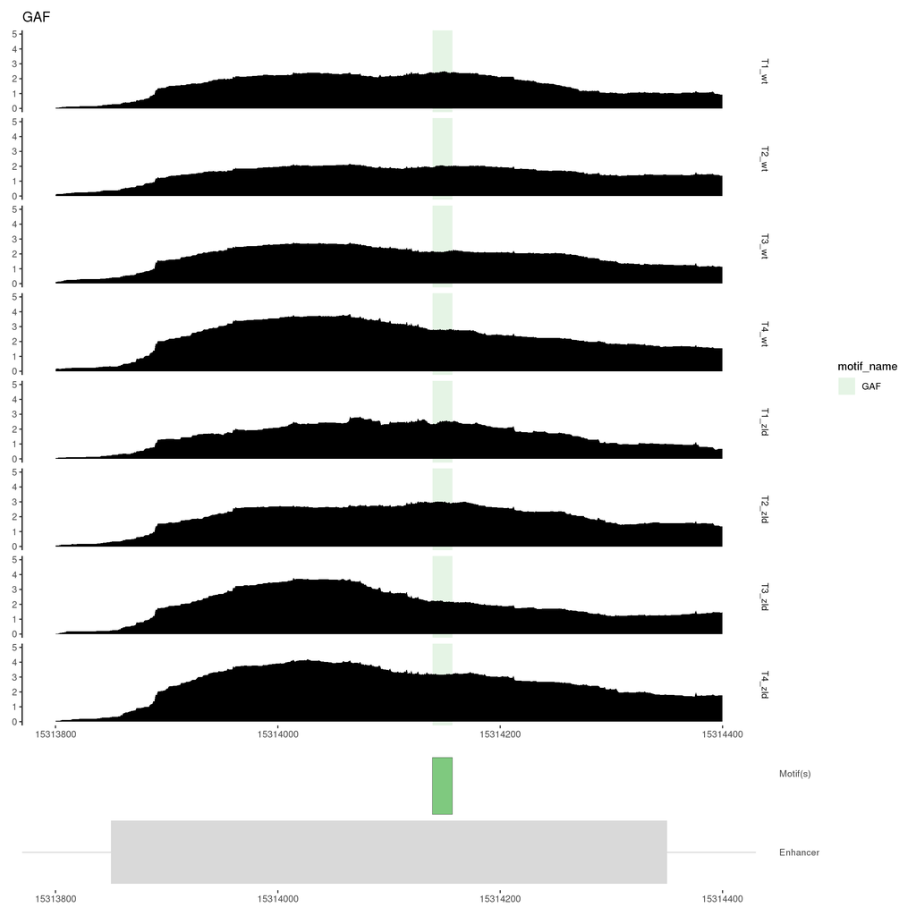

```r
# Define enhancers

enhancers.gr<-c(
  GRanges('chr2R', IRanges(start = 16838950, end = 16839450), strand = '*', name = 'High affinity Zld'),
  GRanges('chr2L', IRanges(start = 19636680, end = 19637180), strand = '*', name = 'Low affinity Zld'),
  GRanges('chr3R', IRanges(start = 15313850, end = 15314350), strand = '*', name = 'GAF'))

# Process motifs

motifs.gr<-readr::read_tsv('/l/Zeitlinger/ZeitlingerLab/Manuscripts/Zelda_and_Nucleosomes/Analysis/analysis/tsv/mapped_motifs/all_instances_curated_1based.tsv.gz') %>%
  makeGRangesFromDataFrame(keep.extra.columns = T, starts.in.df.are.0based = F) %>%
  plyranges::mutate(motif = pattern_name,
                    name = pattern_name) %>%
  GenomicRanges::sort(ignore.strand = T)

#Specific variables
library(RColorBrewer)
n_motifs<-motifs.gr$name %>% unique %>% length
colors <- colorRampPalette(brewer.pal(n_motifs, "Accent"))(n_motifs)
# getPalette(colourCount)
# getPalette = colorRampPalette(brewer.pal(n_motifs, "Set1"))
#
# many_colors <- grDevices::colors()[grep('gr(a|e)y|white', grDevices::colors(), invert = T)]
# many_colors <- many_colors[20:(length(many_colors)-20)]
# step<-floor(length(many_colors) / n_motifs)
# colors <- many_colors[seq(1, n_motifs*step, step)]
names(colors)<-motifs.gr$name %>% unique
motif.colors.list<-as.list(colors)

# Function

plot_coverage_and_enhancer<-function(enhancer.gr, motifs.gr, bw.list, motif.colors.list, title, region_width = 1000,
                                     cores = 6, scales = 'fixed', rounding_margin = 50, label_margin = 200){

  #Assertion requirements to make the function run correctly.
  testit::assert("Input enhancer GRanges needs to contain only 1 region.", length(enhancer.gr)==1)
  testit::assert("Motifs need to be a GRanges object", is(motifs.gr, "GRanges"))
  testit::assert("Enhancers need to be a GRanges object", is(enhancer.gr, "GRanges"))
  testit::assert("Region width should be larger than enhancer width.", width(enhancer.gr)<=region_width)
  testit::assert("Bigwig object needs to be a list of samples. If samples are ChIP-nexus/double-stranded samples, they need to be in a nested list.",
                 is(bw.list, "list") & all(!(names(bw.list) %in% c("pos", "neg"))))
  testit::assert("Motif object needs a column titled pattern_name, motif_name, or name to distinguish motifs apart.",
                 any(grepl("pattern_name|name|motif_name", colnames(motifs.gr@elementMetadata))))

  #Find overlaps between motif set and enhancer
  motifs_in_enhancer.gr<-subsetByOverlaps(motifs.gr, resize(enhancer.gr, region_width, "center"), ignore.strand = T)
  if("pattern_name" %in% colnames(motifs_in_enhancer.gr@elementMetadata)){
    motifs_in_enhancer.gr$motif_name<-motifs_in_enhancer.gr$pattern_name
  }
  if("name" %in% colnames(motifs_in_enhancer.gr@elementMetadata)){
    motifs_in_enhancer.gr$motif_name<-motifs_in_enhancer.gr$name
  }

  #Extract colors for enhancer
  fills_in_order<-lapply(motifs_in_enhancer.gr$motif_name, function(x) motif.colors.list[[x]]) %>% unlist %>% unique %>% as.character
  motifs_in_order<-motifs_in_enhancer.gr$motif_name %>% unique %>% as.character
  motifs_in_enhancer.df<-motifs_in_enhancer.gr %>% as.data.frame
  motifs_in_enhancer.df$motif_name<-factor(motifs_in_enhancer.df$motif_name, levels = motifs_in_order)

  #Convert enhancer coordinates to df
  enhancer.df<-enhancer.gr %>% as.data.frame

  #Get half of the enhancer
  enh_half<-floor(width(enhancer.gr)/2)
  lower_bounds<-plyr::round_any(enhancer.df$start - (region_width/2 - enh_half), rounding_margin, f = floor)
  upper_bounds<-plyr::round_any(enhancer.df$end + (region_width/2 - enh_half), rounding_margin, f = ceiling)

  enhancer.plot<-ggplot()+
    geom_hline(yintercept = .5, color = "gray 85")+
    geom_rect(data = enhancer.df, aes(xmin = start, xmax = end, ymin = 0, ymax = 1), fill = "gray 85")+
    geom_text(data = enhancer.df, aes(x = ((start - end)/2 + start), y = .5, label = paste0(seqnames, ":", start, "-", end)),
              color = "black")
  if(nrow(motifs_in_enhancer.df)>0){
    enhancer.plot<-enhancer.plot + geom_rect(data = motifs_in_enhancer.df,
                                             aes(xmin = start, xmax = end, ymin = 1.1, ymax = 2, fill = motif_name), color = 'black', size = .1)
  }
  enhancer.plot<-enhancer.plot+
    scale_fill_manual(values = fills_in_order)+
    scale_x_continuous(breaks = seq(plyr::round_any(enhancer.df$start - (region_width/2 - enh_half), rounding_margin, f = floor),
                                    plyr::round_any(enhancer.df$end + (region_width/2 - enh_half), rounding_margin, f = ceiling), label_margin),
                       limits = c(lower_bounds,upper_bounds))+
    scale_y_continuous(breaks = c(.5, 1.75), labels = c("Enhancer", "Motif(s)"), position = "right")+
    theme_classic()+
    theme(axis.title = element_blank(), axis.line = element_blank(), axis.ticks.y = element_blank(),
          legend.position = "none")

  # Get coverage across bigwig list
  coverage.df<-mclapply(names(bw.list), function(x){
    if(length(bw.list[[x]])==1){
      df<-standard_metapeak(resize(enhancer.gr, 1, "center"), bw.list[[x]], upstream = floor(region_width/2) + rounding_margin, downstream = floor(region_width/2)+300) %>%
        dplyr::rename(window_distance = tss_distance) %>%
        dplyr::mutate(position = window_distance + start(resize(enhancer.gr, 1, "center")), sample_name = x)
    }
    if(length(bw.list[[x]])==2){
      df<-exo_metapeak(resize(enhancer.gr, 1, "center"), bw.list[[x]], upstream = region_width/2 + rounding_margin, downstream = region_width/2+rounding_margin) %>%
        dplyr::rename(window_distance = tss_distance) %>%
        dplyr::mutate(position = window_distance + start(enhancer.gr), sample_name = x)
    }
    return(df)
  }, mc.cores = cores) %>% rbindlist() %>%
    dplyr::filter(position >= lower_bounds, position <= upper_bounds) %>%
    dplyr::mutate(sample_name = factor(sample_name, levels = names(bw.list)))

  #Check for strand if there are no 2-channeled samples.
  if(!("strand" %in% colnames(coverage.df))){
    coverage.df$strand<-NA
  }

  #Plot the enhancer coverage.
  coverage.plot<-ggplot(coverage.df)
  if(nrow(motifs_in_enhancer.df)>0){
    coverage.plot<-coverage.plot + geom_rect(data = motifs_in_enhancer.df, aes(xmin = start, xmax = end, ymin = -Inf, ymax = Inf, fill = motif_name), alpha = .2)
  }
  coverage.plot<-coverage.plot +
    geom_area(aes(x = position, y = reads, group = strand), fill = "black")+
    geom_text(aes(x = Inf, y = Inf, label = sample_name), hjust = -.01)+
    scale_fill_manual(values = fills_in_order)+
    #scale_x_continuous(breaks = seq(plyr::round_any(enhancer.df$start - (region_width/2 - enh_half), rounding_margin, f = floor),
                                    #plyr::round_any(enhancer.df$end + (region_width/2 - enh_half), rounding_margin, f = ceiling), label_margin),
                       #limits = c(lower_bounds,upper_bounds))+
    facet_grid(sample_name ~ .)+
    ylim(0,5)+
    ggtitle(title)+
    theme_classic()+
    theme(axis.title = element_blank(), axis.line.x = element_blank(), strip.background = element_blank())

  g<-coverage.plot + enhancer.plot + plot_layout(ncol = 1, heights = c(5, 1))
  return(g)
}

# Plot regions

mclapply(1:length(enhancers.gr), function(x){
  enhancer.gr = enhancers.gr[x]
  g<-plot_coverage_and_enhancer(enhancer.gr = enhancer.gr, motifs.gr = motifs.gr, bw.list = bw.list,
                                motif.colors.list = motif.colors.list, title = enhancer.gr$name,
                                region_width = width(enhancer.gr), cores = 6, scales = 'fixed')
  ggsave(paste0("figures/14_zelda_depletion_atac/", enhancer.gr$name,"_single_example.pdf"), g, height = 15, width = 20)
  ggsave(paste0("figures/14_zelda_depletion_atac/", enhancer.gr$name,"_single_example.png"), g, height = 15, width = 20)
  return(g)
}, mc.cores = 4)
```

## 7.8. Plot average binding profiles at these same regions

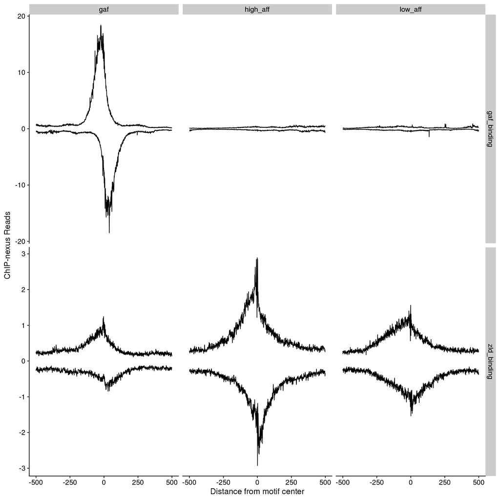

```r
# Import relevant data

binding.list <- list(zld_binding = list(pos = '/l/Zeitlinger/ZeitlingerLab/Manuscripts/Zelda_and_Nucleosomes/Analysis/data/bw/dm6/nexus/combined/orer_zld_mbt_nexus_combined_positive.bw',
                                        neg = '/l/Zeitlinger/ZeitlingerLab/Manuscripts/Zelda_and_Nucleosomes/Analysis/data/bw/dm6/nexus/combined/orer_zld_mbt_nexus_combined_negative.bw'),
                     gaf_binding = list(pos = '/l/Zeitlinger/ZeitlingerLab/Manuscripts/Zelda_and_Nucleosomes/Analysis/data/bw/dm6/nexus/combined/orer_gaf_mbt_nexus_combined_positive.bw',
                                        neg = '/l/Zeitlinger/ZeitlingerLab/Manuscripts/Zelda_and_Nucleosomes/Analysis/data/bw/dm6/nexus/combined/orer_gaf_mbt_nexus_combined_negative.bw'))

# Define function

get_multi_gr_bw_exo_metapeak <- function(gr.list = gr.list, bw = bw.list, upstream = 500, downstream = 500, smooth = NA){
  mclapply(names(gr.list), function(x){
    gr <- gr.list[[x]]
    get_multi_bw_exo_metapeak(gr,bw.list, upstream = upstream, downstream = downstream, smooth = smooth) %>%mutate(grange_name = x)# The ample_name will be the bw name
  },mc.cores = 10) %>% bind_rows() %>% rename(bw_name = sample_name)
}

# Calculate and plot

metapeaks.df <- lapply(names(zld_aff.list), function(x){
  gr <- zld_aff.list[[x]]
  df_across_samples<-lapply(names(binding.list), function(y){
    bw <- binding.list[[y]]
    df <- exo_metapeak(gr = resize(gr, 1, "center"), sample = bw, upstream = 500, downstream = 500)
    df$regions <- x
    df$chip <- y
    return(df)
  }) %>% rbindlist
  return(df_across_samples)
}) %>% rbindlist

binding.aff <- ggplot(metapeaks.df, aes(x=tss_distance, y=reads, fill=strand))+
  geom_line(aes(group=strand))+
  facet_grid(chip ~ regions, scales = "free_y")+
  xlab("Distance from motif center")+
  ylab("ChIP-nexus Reads")+
  theme_cowplot()
binding.aff
```

```r
ggsave("binding_at_affinity_regions.pdf", plot = binding.aff, path = "figures/14_zelda_depletion_atac", width = 40, height = 20, units = "cm")
ggsave("binding_at_affinity_regions.png", plot = binding.aff, path = "figures/14_zelda_depletion_atac", width = 40, height = 20, units = "cm")
```

# 8. Conclusions

Here we can see that there is a general decrease in accessibility at Zelda-motif containing regions, in agreement with what has been previously pubslished in regard to Zelda’s known role as a pioneer. Additionally, we see that low affinity motifs also work for pioneering but that they aren’t as strong as high affinity motifs, and we find this by comparing wt and zld- ATAC-seq time course data at individual Zelda motif instances.